**Discrete Signal Processing (DSP):**  
**Linear Time-Invariant (LTI) Systems**

Table of Contents

# 1. Linear Time-Invariant (LTI) Systems

A discrete-time system $H$ is a transformation that maps an input signal $x[n]$ to an output signal $y[n]$:

$$ y[n] = H\{x[n]\} $$

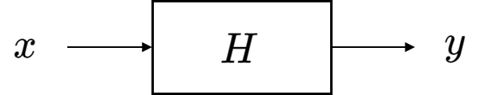

**System Examples**

Below are some typical system behaviors:

$$ \begin{aligned} \text{Identity} &\qquad y[n] = x[n] \\ \text{Scaling} &\qquad y[n] = 2x[n] \\ \text{Offset} &\qquad y[n] = x[n] + 2 \\ \text{Nonlinearity} &\qquad y[n] = (x[n])^2 \\ \text{Shift} &\qquad y[n] = x[n + 2] \\ \text{Decimation} &\qquad y[n] = x[2n] \\ \text{Index Squaring} &\qquad y[n] = x[n^2] \end{aligned} $$

Each of these systems modifies the input signal according to a specific rule. The remaining sections will focus on those systems that are linear and time-invariant, as they are fundamental to signal processing theory.

## 1.1. Linear Systems

A system $H$ is linear if it satisfies:

**(1) Scaling:**

$$ H\{\alpha x[n]\} = \alpha H\{x[n]\}, \quad \forall \alpha \in \mathbb{C} $$

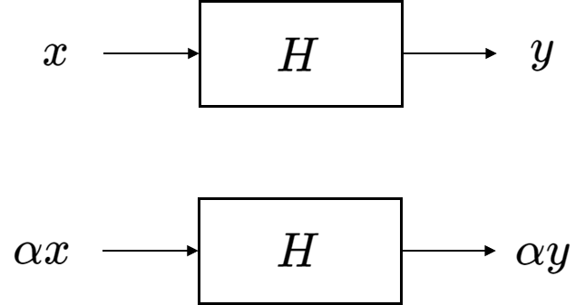

**(2) Additivity:**

If $ y_1 [n] = H\{x_1 [n]\} $ and $ y_2 [n] = H\{x_2 [n]\} $, then

$$ H\{x_1[n] + x_2[n]\} = y_1[n] + y_2[n] $$

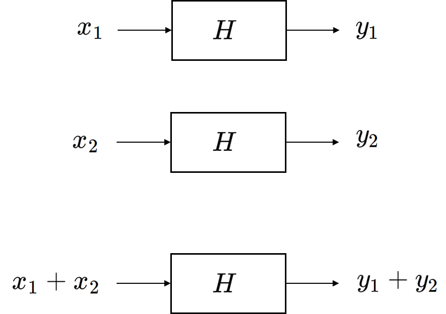

**Matrix Multiplication and Linear Systems**

Matrix multiplication serves as a fundamental computational model for representing linear systems in signal processing. It provides a compact and expressive way to encode how input signals are linearly transformed into output signals.

Let $H$ denote a matrix representing the linear system, and let $x$ be the input vector (i.e., the signal). The output $y$ of the system is given by the matrix-vector product:

$$ \begin{aligned} y &= Hx \\\\ y[n] &= \sum_m H_{n,m} \, x[m] = \sum_m h_{n,m} \, x[m] \end{aligned} $$

Here, $h_{n,m} = H_{n,m}$ is the element in the $n$-th row and $m$-th column of the matrix $H$, indicating how input $x[m]$ contributes to output $y[n]$.

Surprisingly, any linear system can be fully described by a matrix multiplication. The matrix $H$ captures the influence of each input component on each output component.

**Two Interpretations of Matrix Multiplication**

Matrix multiplication can be understood through two complementary perspectives:

**(1) Column-wise view**

The output $y$ is a linear combination of the columns of $H$, weighted by the entries of the input vector $x$:

$$ y = x[0] \cdot H[:,0] + x[1] \cdot H[:,1] + \cdots + x[M-1] \cdot H[:,M-1] $$

This emphasizes how each column of the matrix contributes to the final output.

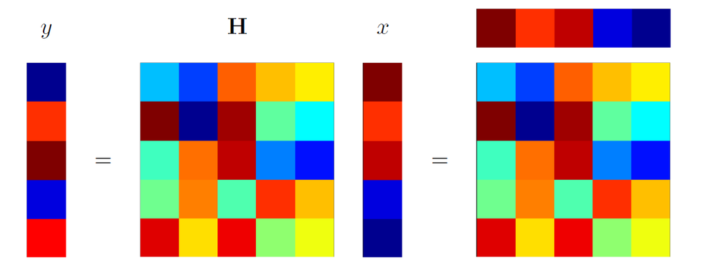

**(2) Row-wise view**

Each output component $y[n]$ is the inner product of the $n$-th row of $H$ with the input vector $x$:

$$ y[n] = \langle H[n,:],\, x \rangle $$

This highlights the computation of each output sample as a weighted sum of the input signal.

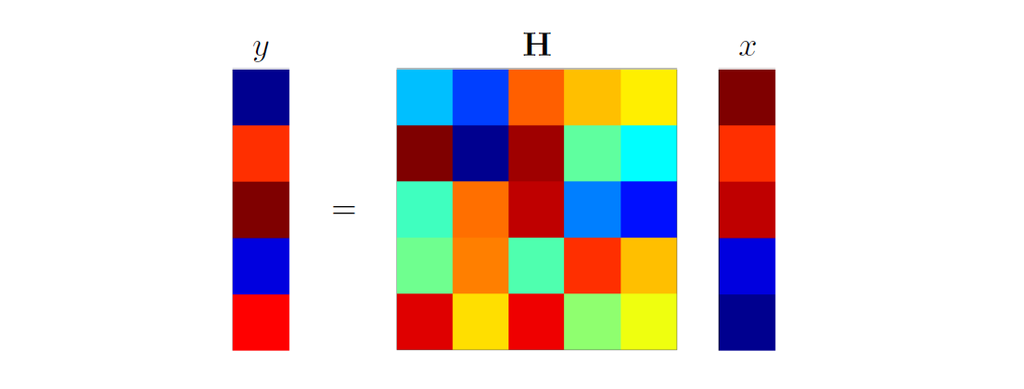

These two perspectives are essential for both understanding the structure of linear systems and implementing them efficiently in practice.

## 1.2. Time-Invariant Systems

A system $H$ is called time-invariant (or shift-invariant) if a shift in the input signal results in an identical shift in the output signal. This property ensures that the system's behavior does not depend on the absolute timing of the input. It reacts the same way regardless of when a signal is applied.

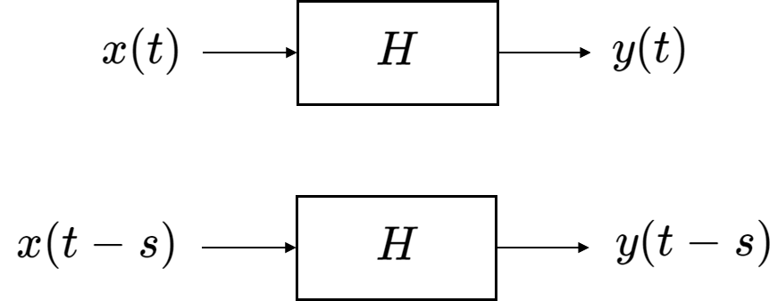

**(1) Time-Invariance for Infinite-Length Signals**

For systems operating on infinite-length (i.e., unbounded) discrete-time signals, time-invariance is formally defined as:

$$ H\{x[n - q]\} = y[n - q] \quad \text{for all integers } q $$

This means that if the input signal is delayed by $q$ samples, the output will also be delayed by $q$ samples, with no change in shape or amplitude.

**(2) Time-Invariance for Finite-Length Signals**

For systems that operate on signals of fixed length $N$, indexing is handled modulo-$N$ to preserve signal length after shifts. In this case, the time-invariance condition is expressed as:

$$ H\{x[(n - q)_N]\} = y[(n - q)_N] $$

Here, $(n - q)_N$ denotes modulo-$N$ circular indexing, which wraps the delayed indices around the signal length $N$.

This circular shift formulation is essential when defining **circular convolution** and performing system analysis in the frequency domain using the Discrete Fourier Transform (DFT).

Understanding time-invariance under both linear and circular shifting is crucial for designing and analyzing digital filters, especially when working with periodic or block-based signal processing systems.

## 1.3. Linear Time-Invariant (LTI) Systems

A system $H$ is said to be linear time-invariant (LTI) if it satisfies both linearity and time-invariance properties. These systems form the foundation of digital signal processing and enjoy powerful analytical tools. In this course, we will primarily focus on LTI systems.

Examples of System Properties

$$ \begin{aligned} \text{Identity} &\qquad y[n] = x[n] &\quad \text{Linear} &\quad \text{Time-Invariant} \\ \text{Scaling} &\qquad y[n] = 2\,x[n] &\quad \text{Linear} &\quad \text{Time-Invariant} \\ \text{Offset} &\qquad y[n] = x[n] + 2 &\quad \text{Nonlinear} &\quad \text{Time-Invariant} \\ \text{Square Signal} &\qquad y[n] = (x[n])^2 &\quad \text{Nonlinear} &\quad \text{Time-Invariant} \\ \text{Shift} &\qquad y[n] = x[n+2] &\quad \text{Linear} &\quad \text{Time-Invariant} \\ \text{Decimation} &\qquad y[n] = x[2n] &\quad \text{Linear} &\quad \text{Time-Variant} \\ \text{Nonlinear Index} &\qquad y[n] = x[n^2] &\quad \text{Linear} &\quad \text{Time-Variant} \end{aligned} $$

### 1.3.1. LTI Systems as Matrix Multiplications (Infinite-Length Signals)

For infinite-length signals, a general linear system is expressed as:

$$ y[n] = H\{x[n]\} = \sum_{m=-\infty}^{\infty} h_{n,m} \, x[m] $$

Time-invariance implies:

$$ H\{x[n - q]\} = y[n - q] = \sum_{m=-\infty}^{\infty} h_{n,m} \, x[m - q] $$

Using a change of variables: $n' = n - q$, $m' = m - q$

$$ H\{x[n']\} = \sum_{m=-\infty}^{\infty} h_{n'+q, m'+q} \, x[m'] $$

Matching expressions reveals the structure:

$$ h_{n,m} = h_{n+q, m+q} $$
$$H = \begin{bmatrix}&\vdots&\vdots&\vdots&\\ \cdots&h_{-1,-1}&h_{-1,0}&h_{-1,1}&\cdots\\ \cdots&h_{0,-1}&h_{0,0}&h_{0,1}&\cdots\\ \cdots&h_{1,-1}&h_{1,0}&h_{1,1}&\cdots\\ &\vdots&\vdots&\vdots&\\ \end{bmatrix}= \begin{bmatrix}&\vdots&\vdots&\vdots&\\ \cdots&h_{0,0}&h_{-1,0}&h_{-2,0}&\cdots\\ \cdots&h_{1,0}&h_{0,0}&h_{-1,0}&\cdots\\ \cdots&h_{2,0}&h_{1,0}&h_{0,0}&\cdots\\ &\vdots&\vdots&\vdots&\\ \end{bmatrix}$$

This implies $h_{n,m}$ depends only on the difference $n - m$, so we write:

$$ h_{n,m} = h[n - m] $$

The matrix representation becomes Toeplitz (constant along diagonals):

- The entire matrix is determined by the impulse response $h[n] = h_{n,0}$
- Diagonals are constant: $[H]_{n,m} = h[n - m]$

$$H = \begin{bmatrix} \ddots &\vdots&\vdots&\vdots&\cdots\\ \cdots&h_{0,0}&h_{-1,0}&h_{-2,0}&\cdots\\ \cdots&h_{1,0}&h_{0,0}&h_{-1,0}&\cdots\\ \cdots&h_{2,0}&h_{1,0}&h_{0,0}&\cdots\\ &\vdots&\vdots&\vdots&\ddots\\ \end{bmatrix}= \begin{bmatrix} \ddots & \vdots & \vdots & \vdots & \cdots \\ \cdots & h[0] & h[-1] & h[-2] & \cdots \\ \cdots & h[1] & h[0] & h[-1] & \cdots \\ \cdots & h[2] & h[1] & h[0] & \cdots \\ \cdots & \vdots & \vdots & \vdots & \ddots \end{bmatrix} $$

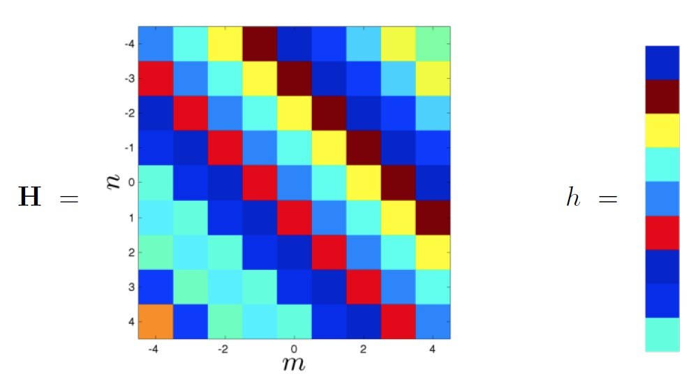

All of the entries in a Toeplitz matrix can be expressed in terms of the entries of its 0-th column:

$$h[n] = h_{n,0}$$

This is a remarkable observation: it aligns perfectly with the foundational fact that a linear time-invariant (LTI) system is completely characterized by its impulse response $h[n]$. Once the impulse response is known, we can construct the full system matrix $H$, which governs how the system acts on any input signal.

### 1.3.2. LTI Systems for Finite-Length Signals

For signals of fixed length $N$, the linear system is expressed as:

$$ y[n] = H\{x[n]\} = \sum_{m=0}^{N-1} h_{n,m} \, x[m] $$

Time-invariance for circular (modulo-$N$) signals implies:

$$ H\{x[(n - q)_N]\} = y[(n - q)_N] = \sum_{m=0}^{N-1} h_{n,m} \, x[(m - q)_N] $$

Change of variables: $n' = n - q$, $m' = m - q$

$$ H\{x[n']\} = \sum_{m=0}^{N-1} h_{(n'+q)_N, (m'+q)_N} \, x[m'] $$

Thus,

$$ h_{n,m} = h_{(n + q)_N, (m + q)_N} $$
$$H = \begin{bmatrix}h_{0,0}&h_{0,1}&h_{0,2}&\cdots&h_{0,N-1}\\ h_{1,0}&h_{1,1}&h_{1,2}&\cdots&h_{1,N-1}\\ h_{2,0}&h_{2,1}&h_{2,2}&\cdots&h_{2,N-1}\\ \vdots&\vdots&\vdots&&\vdots\\ h_{N-1,0}&h_{N-1,1}&h_{N-1,2}&\cdots&h_{N-1,N-1}\\ \end{bmatrix}= \begin{bmatrix}h_{0,0}&h_{N-1,0}&h_{N-2,0}&\cdots&h_{1,0}\\ h_{1,0}&h_{0,0}&h_{N-1,0}&\cdots&h_{2,0}\\ h_{2,0}&h_{1,0}&h_{0,0}&\cdots&h_{3,0}\\ \vdots&\vdots&\vdots&&\vdots\\ h_{N-1,0}&h_{N-2,0}&h_{N-3,0}&\cdots&h_{0,0}\\ \end{bmatrix}$$

This implies the structure:

$$ h_{n,m} = h[(n - m)_N] $$

The matrix $H$ is a circulant matrix, fully determined by the first column:

$$H = \begin{bmatrix}h_{0,0}&h_{N-1,0}&h_{N-2,0}&\cdots&h_{1,0}\\ h_{1,0}&h_{0,0}&h_{N-1,0}&\cdots&h_{2,0}\\ h_{2,0}&h_{1,0}&h_{0,0}&\cdots&h_{3,0}\\ \vdots&\vdots&\vdots&&\vdots\\ h_{N-1,0}&h_{N-2,0}&h_{N-3,0}&\cdots&h_{0,0}\\ \end{bmatrix}= \begin{bmatrix}h[0]&h[N-1]&h[N-2]&\cdots&h[1]\\ h[1]&h[0]&h[N-1]&\cdots&h[2]\\ h[2]&h[1]&h[0]&\cdots&h[3]\\ \vdots&\vdots&\vdots&&\vdots\\ h[N-1]&h[N-2]&h[N-3]&\cdots&h[0]\\ \end{bmatrix}$$

Row-$n$, column-$m$ entry is:

$$ [H]_{n,m} = h[(n - m)_N] $$

Notice the structure of the diagonals and the circular shifts.

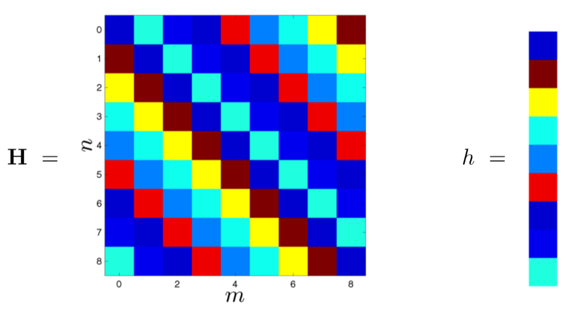

This structure is fundamental to circular convolution, and its properties enable fast implementation via the Discrete Fourier Transform (DFT).

# 2. Impulse Response

In the study of linear time-invariant (LTI) systems, the impulse response plays a fundamental role. It provides a complete characterization of the system's behavior and allows us to construct the system matrix $H$ or compute the system's output via convolution.

**Definition of the Impulse Signal**

The discrete-time impulse signal $\delta[n]$, also called the delta function, is defined as:

$$ \delta[n] = \begin{cases} 1 & \text{if } n = 0 \\ 0 & \text{otherwise} \end{cases} $$

It serves as a probing signal that isolates the response of the system at a single time index.

## 2.1. Impulse Response of an LTI System

Let $H$ denote a discrete-time LTI system. The impulse response of the system, denoted $h[n]$, is the output when the input is $\delta[n]$:

$$ h[n] = H\{\delta[n]\} $$

This signal $h[n]$ contains all information about the system's behavior and can be used to determine the system output for any arbitrary input via convolution.

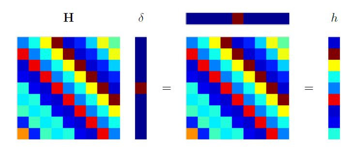

For linear time-invariant (LTI) systems, the impulse response uniquely characterizes the system. Specifically:

- The system output for any input $x[n]$ is given by the convolution:

$$ y[n] = \sum_{m=-\infty}^{\infty} h[n - m]\, x[m] $$

- When the input is $\delta[n]$, the output reduces to:

$$ y[n] = \sum_{m=-\infty}^{\infty} h[n - m]\, \delta[m] = h[n] $$

This confirms that $h[n]$ is the system's response to the impulse input.

Moreover, the impulse response determines the matrix representation of the system:

- The matrix $H$ can be constructed from $h[n]$, with each row (or column) being a shifted version of the impulse response
- For infinite-length signals, LTI systems correspond to Toeplitz matrices, where the entries satisfy:

$$ [H]_{n,m} = h[n - m] $$

That is, all elements along any given diagonal are equal.

Hence, the impulse response encapsulates all the information necessary to describe an LTI system, both analytically (via convolution) and structurally (via the system matrix).

## 2.2. Examples (Infinite-Length Signals)

In this example, we will compute the system matrix $H$ and, more importantly, visualize it in order to gain deeper insight into the impulse responses of various linear time-invariant (LTI) systems.

$$H= \begin{bmatrix}&\vdots&\color{red}{\vdots}&\vdots&\\ \cdots&h[0]&\color{red}{h[-1]}&h[-2]&\cdots\\ \cdots&h[1]&\color{red}{h[0]}&h[-1]&\cdots\\ \cdots&h[2]&\color{red}{h[1]}&h[0]&\cdots\\ &\vdots&\color{red}{\vdots}&\vdots&\\ \end{bmatrix} $$

(1) Impulse response of the scaling system

$$ \begin{align*} h[n] &= 2\delta[n]\\\\ H_{n,m} &= h[n-m] \end{align*} $$

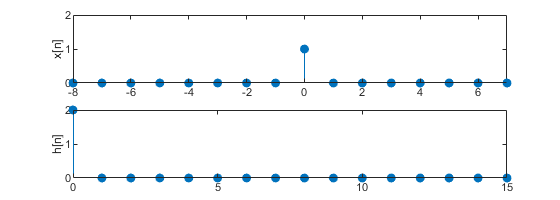

```matlab
%plot -s 560,200

N = 8;
nh = [0:2*N-1];
nx = [-N:N-1];

x = zeros(size(nx))';
x(N+1) = 1;

h = zeros(size(nh))';
h(1) = 2;

subplot(2,1,1), stem(nx,x,'filled'), ylabel('x[n]'), axis tight, ylim([0,2])
subplot(2,1,2), stem(nh,h,'filled'), ylabel('h[n]'), axis tight, ylim([0,2])
```

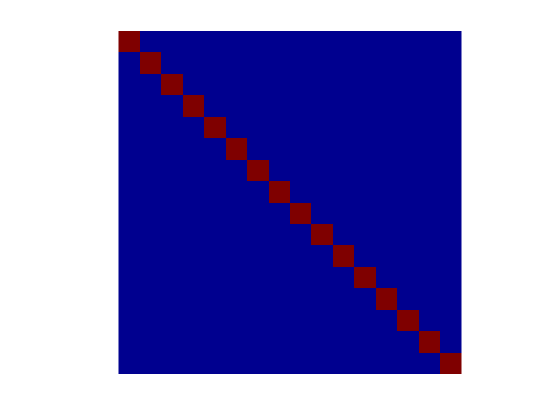

```matlab
%plot -s 560,420

hc = h;
hr = [h(1),zeros(1,length(x)-1)];
H = toeplitz(hc,hr);

imagesc(H); colormap('jet'); axis('square'); axis off
```

(2) Impulse response of the shift system

$$ \begin{align*} h[n] &= \delta[n-3]\\\\ H_{n,m} &= h[n-m] \end{align*} $$

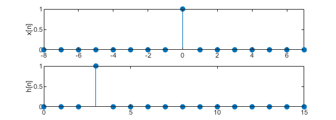

```matlab
%plot -s 560,200

N = 8;
nh = [0:2*N-1];
nx = [-N:N-1];

x = zeros(size(nx))';
x(N+1) = 1;

h = zeros(size(nh))';
h(4) = 1;

subplot(2,1,1), stem(nx,x,'filled'), ylabel('x[n]'), axis tight, ylim([0,1])
subplot(2,1,2), stem(nh,h,'filled'), ylabel('h[n]'), axis tight, ylim([0,1])
```

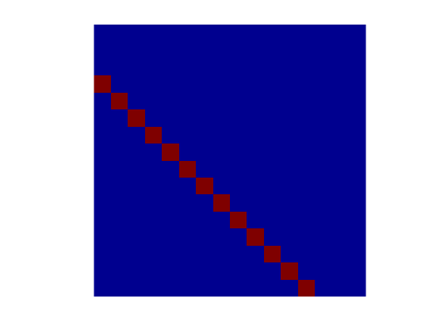

```matlab
%plot -s 560,420

hc = h;
hr = [h(1),zeros(1,length(x)-1)];
H = toeplitz(hc,hr);

imagesc(H); colormap('jet'); axis('square'); axis off
```

(3) Impulse response of the moving average system

$$ \begin{align*} h[n] &= \frac{1}{3}(\delta[n] + \delta[n-1] + \delta[n-2])\\\\ H_{n,m} = h[n-m] &= \frac{1}{3}(\delta[n-m] + \delta[n-m-1] + \delta[n-m-2]) \end{align*} $$

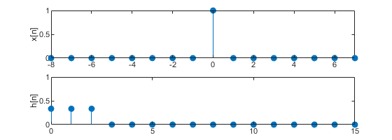

```matlab
%plot -s 560,200

N = 8;
nh = [0:2*N-1];
nx = [-N:N-1];

x = zeros(size(nx))';
x(N+1) = 1;

h = zeros(size(nh))';
h(1) = 1/3;
h(2) = 1/3;
h(3) = 1/3;

subplot(2,1,1), stem(nx,x,'filled'), ylabel('x[n]'), axis tight, ylim([0,1])
subplot(2,1,2), stem(nh,h,'filled'), ylabel('h[n]'), axis tight, ylim([0,1])
```

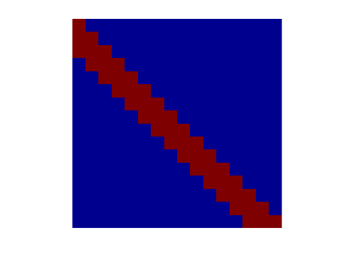

```matlab
%plot -s 560,420

hc = h;
hr = [h(1),zeros(1,length(x)-1)];
H = toeplitz(hc,hr);

imagesc(H); colormap('jet'); axis('square'); axis off
```

(4) Impulse response of the recursive average system

$$y[n] = x[n] + \alpha y[n-1]$$
$$ \begin{align*} h[n] &= \alpha^n u[n]\\\\ H_{n,m} = h[n-m] &= \alpha^{n-m}u[n-m] \end{align*} $$

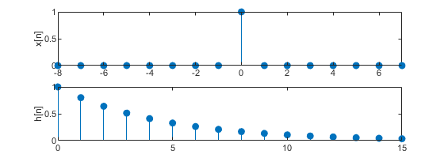

```matlab
%plot -s 560,200

N = 8;
nh = [0:2*N-1];
nx = [-N:N-1];

x = zeros(size(nx))';
x(N+1) = 1;

h = 0.8.^nh;
h = h';

subplot(2,1,1), stem(nx,x,'filled'), ylabel('x[n]'), axis tight, ylim([0,1])
subplot(2,1,2), stem(nh,h,'filled'), ylabel('h[n]'), axis tight, ylim([0,1])
```

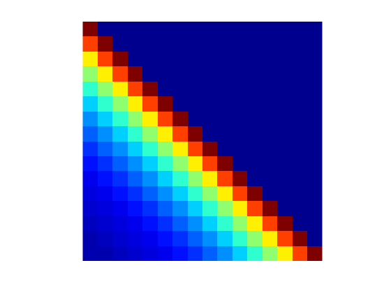

```matlab
%plot -s 560,420

hc = h;
hr = [h(1),zeros(1,length(x)-1)];
H = toeplitz(hc,hr);

imagesc(H); colormap('jet'); axis('square'); axis off
```

## 3.3. Examples (Finite-Length Signals)

We now repeat the visualization for finite-length signals. In this case, the resulting system matrix exhibits constant values along its diagonals, together with circular wraparound, which is characteristic of a circulant matrix.

$$h_{n,m} = h_{(n+q)_N (m+q)_N} \qquad \forall q \in \mathbb{Z}$$
$$ H = \begin{bmatrix}\color{red}{h[0]}&h[N-1]&h[N-2]&\cdots&h[1]\\ \color{red}{h[1]}&h[0]&h[N-1]&\cdots&h[2]\\ \color{red}{h[2]}&h[1]&h[0]&\cdots&h[3]\\ \vdots&\vdots&\vdots&&\vdots\\ \color{red}{h[N-1]}&h[N-2]&h[N-3]&\cdots&h[0]\\ \end{bmatrix} $$

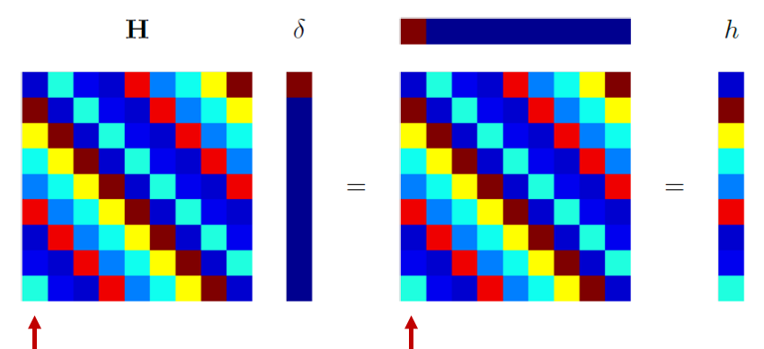

(1) Impulse response of the shift system

$$ \begin{align*} h[n] &= \delta[n-2]\\\\ H_{n,m} &= h[(n-m)_N] \end{align*} $$

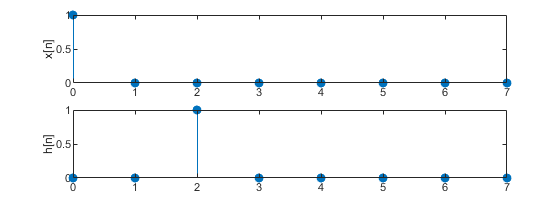

```matlab
%plot -s 560,200

N = 8;
nh = [0:N-1];
nx = [0:N-1];

x = zeros(size(nx))';
x(1) = 1;

h = zeros(size(nh))';
h(3) = 1;

subplot(2,1,1), stem(nx,x,'filled'), ylabel('x[n]'), axis tight, ylim([0,1])
subplot(2,1,2), stem(nh,h,'filled'), ylabel('h[n]'), axis tight, ylim([0,1])
```

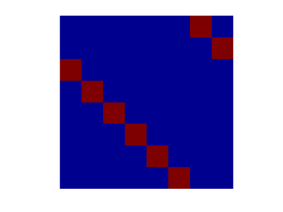

```matlab
%plot -s 560,420

H = zeros(N,N);

for k = 0:N-1
    H(:,k+1) = circshift(h,k);
end

imagesc(H); colormap('jet'); axis('square'); axis off
```

(2) Impulse response of the moving average system

$$ \begin{align*} h[n] &= \frac{1}{3}(\delta[n] + \delta[n-1] + \delta[n-2])\\\\ H_{n,m} &= h[(n-m)_N] \end{align*} $$

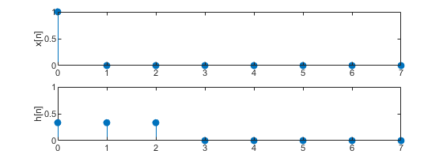

```matlab
%plot -s 560,200

N = 8;
nh = [0:N-1];
nx = [0:N-1];

x = zeros(size(nx))';
x(1) = 1;

h = zeros(size(nh))';
h(1) = 1/3;
h(2) = 1/3;
h(3) = 1/3;

subplot(2,1,1), stem(nx,x,'filled'), ylabel('x[n]'), axis tight, ylim([0,1])
subplot(2,1,2), stem(nh,h,'filled'), ylabel('h[n]'), axis tight, ylim([0,1])
```

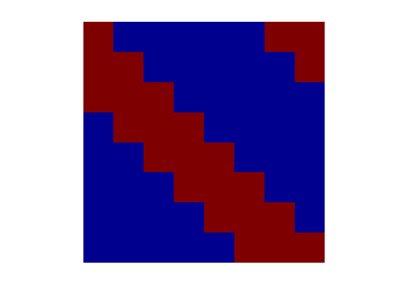

```matlab
%plot -s 560,420

H = zeros(N,N);

for k = 0:N-1
    H(:,k+1) = circshift(h,k);
end

imagesc(H); colormap('jet'); axis('square'); axis off
```

(3) Impulse response of the recursive average system

$$y[n] = x[n] + \alpha y[n-1]$$
$$ \begin{align*} h[n] &= \alpha^n u[n]\\\\ H_{n,m} &= h[(n-m)_N] \end{align*} $$

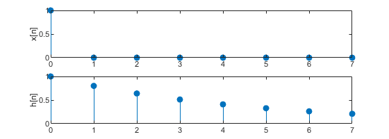

```matlab
%plot -s 560,200

N = 8;
nh = [0:N-1];
nx = [0:N-1];

x = zeros(size(nx))';
x(1) = 1;

h = zeros(size(nh))';
h = 0.8.^nh;

subplot(2,1,1), stem(nx,x,'filled'), ylabel('x[n]'), axis tight, ylim([0,1])
subplot(2,1,2), stem(nh,h,'filled'), ylabel('h[n]'), axis tight, ylim([0,1])
```

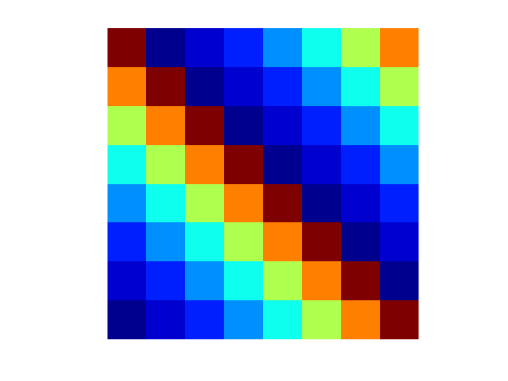

```matlab
%plot -s 560,420

H = zeros(N,N);

for k = 0:N-1
    H(:,k+1) = circshift(h,k);
end

imagesc(H); colormap('jet'); axis('square'); axis off
```

# 3. Convolution

Convolution is a fundamental operation in linear systems theory. For discrete-time signals, convolution describes the output of an LTI system as the weighted sum of shifted and reversed versions of the input signal.

The convolution of an input signal $x[n]$ with a system’s impulse response $h[n]$ is defined as:

$$ y[n] = \sum_{m = -\infty}^{\infty} h[n - m]\, x[m] = x[n] * h[n] $$

This expression means that the output $y[n]$ is obtained by convolving the input $x[n]$ with the system's impulse response $h[n]$.

**Commutativity**: Convolution is commutative, which means the order of operands does not matter:

$$ x * h = h * x $$

This can be seen by a change of variables in the convolution sum:

$$ \begin{aligned} y[n] &= \sum_{m = -\infty}^{\infty} h[n - m]\, x[m] \\ &= \sum_{k = -\infty}^{\infty} h[k]\, x[n - k] \qquad \text{(where } k = n - m \text{)} \\ &= \sum_{k = -\infty}^{\infty} x[n - k]\, h[k] \end{aligned} $$

Thus, convolution is symmetric with respect to the input signal and the system impulse response: we may think of either as the "signal" and the other as the "system".

**(MATLAB Code) Convolution**

$$\begin{align*} x[n]=\{3,11,7,&\;0,-1,4,2\}\quad \quad -3\leq n \leq 3\\ &\uparrow \\\\ h[n]=\{2,&\;3,0,-5,2,1\}\quad \quad -1\leq n \leq 4\\ &\uparrow \end{align*} $$

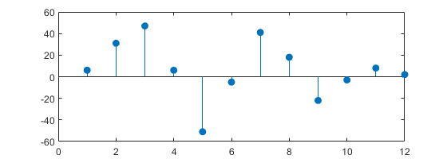

```matlab
%plot -s 560,200

%% matlab command 'conv'
x = [3,11,7,0,-1,4,2];
h = [2,3,0,-5,2,1];
y = conv(x,h);

stem(y,'filled'), ylim([-60 60])

% this is not correct
```

You have to include `conv_m` function file in the path.

```
function [y,ny] = conv_m(x,nx,h,nh)

% Modified convolution routine for signal processing
% [y,ny] = conv_m(x,nx,h,nh)
%  y = convolution result
% ny = support of y
%  x = first signal on support nx
% nx = support of x
%  h = second signal on support nh
% nh = support of h

nyb = nx(1) + nh(1);
nye = nx(length(x)) + nh(length(h));
ny = [nyb:nye];
y = conv(x,h);
```

$$\begin{align*} x[n]=\{3,11,7,&\;0,-1,4,2\}\quad \quad -3\leq n \leq 3\\ &\uparrow \\\\ h[n]=\{2,&\;3,0,-5,2,1\}\quad \quad -1\leq n \leq 4\\ &\uparrow \end{align*} $$

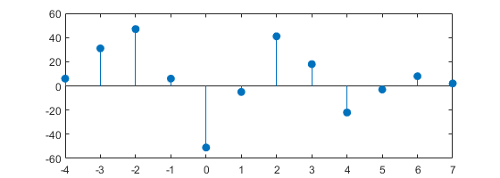

```matlab
%plot -s 560,200

x = [3,11,7,0,-1,4,2];  nx = [-3:3];
h = [2,3,0,-5,2,1];     nh = [-1:4];

[y,ny] = conv_m(x,nx,h,nh);

stem(ny,y,'filled'), axis tight, ylim([-60 60])

% this is what we want
```

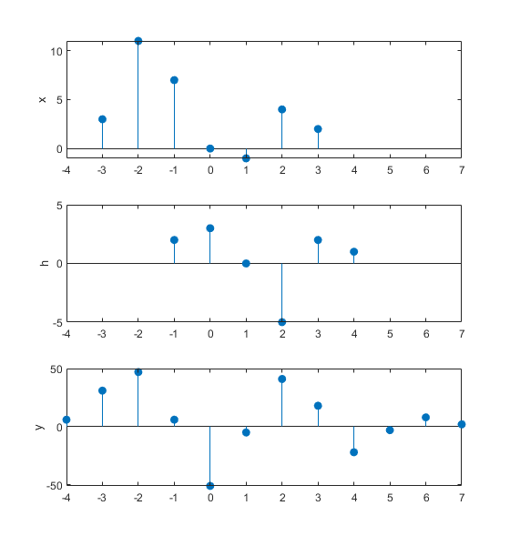

```matlab
%plot -s 560,600

subplot(3,1,1), stem(nx,x,'filled'); xlim([ny(1),ny(end)]);  ylabel('x')
subplot(3,1,2), stem(nh,h,'filled'); xlim([ny(1),ny(end)]);  ylabel('h')
subplot(3,1,3), stem(ny,y,'filled'); xlim([ny(1),ny(end)]);  ylabel('y')
```

## 3.1. Convolution for Infinite-Length Signals

For systems operating on infinite-length discrete-time signals, convolution is mathematically equivalent to multiplying the input signal by a **Toeplitz matrix**.

The output signal $y[n]$ is given by the convolution sum:

$$ \begin{aligned} y[n] &= (x * h)[n] = \sum_{m = -\infty}^{\infty} h[n - m]\, x[m] \\\\ &= \cdots + h[n + 2]\, x[-2] + h[n + 1]\, x[-1] + h[n]\, x[0] + h[n - 1]\, x[1] + h[n - 2]\, x[2] + \cdots \end{aligned} $$

This expression represents an inner product between a shifted (and flipped) version of the impulse response $h$ and the input signal $x$. For each $n$, the vector $h[n - m]$ aligns with $x[m]$, and their pointwise product is summed to compute $y[n]$.

In matrix notation, the convolution can be written as:

$$ y[n] = H x $$

where $H$ is a Toeplitz matrix whose rows are shifted versions of the impulse response:

$$ \begin{align*} y[n] &= \begin{bmatrix} \cdots & \mid & \mid & \mid & \mid & \mid & \cdots\\ \cdots & h[n+2] & h[n+1] & h[n] & h[n-1] & h[n-2]\ & \cdots\\ \cdots & \mid & \mid & \mid & \mid & \mid & \cdots \end{bmatrix} \begin{bmatrix} \vdots\\ x[-2]\\ x[-1]\\ x[0]\\ x[1]\\ x[2]\\ \vdots \end{bmatrix}\\ \\ &= H x \end{align*} $$

Thus, convolution with an LTI system corresponds to multiplying the input vector $x$ by a structured matrix $H$ whose diagonal-constant structure reflects the system's time-invariance.

Convolution is product of matrix $H$ and $x$.

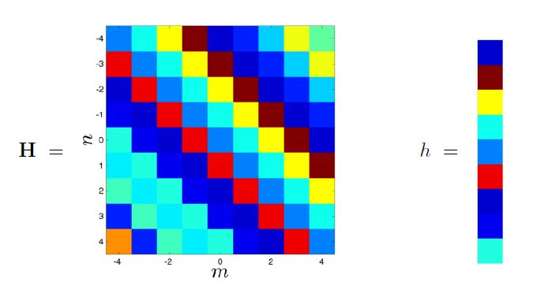

```matlab
x = [3, 11, 7, 0, -1, 4, 2]';
h = [2, 3, 0, -5, 2, 1]';

hc = [h,zeros([length(x)-1,1])];
hr = [h(1),zeros([1,length(x)-1])];
H = toeplitz(hc,hr)

y = H*x
```

```
H =

     2     0     0     0     0     0     0
     3     2     0     0     0     0     0
     0     3     2     0     0     0     0
    -5     0     3     2     0     0     0
     2    -5     0     3     2     0     0
     1     2    -5     0     3     2     0
     0     1     2    -5     0     3     2
     0     0     1     2    -5     0     3
     0     0     0     1     2    -5     0
     0     0     0     0     1     2    -5
     0     0     0     0     0     1     2
     0     0     0     0     0     0     1


y =

     6
    31
    47
     6
   -51
    -5
    41
    18
   -22
    -3
     8
     2
```